# Data visualisation

## 1.7 통계적 변환

- 이번에 살펴볼 그래프는 막대그래프이다.
- 가격(price), 캐럿(carat), 색상(color), 투명도(clarity), 컷(cut)등의 정보가 있다.

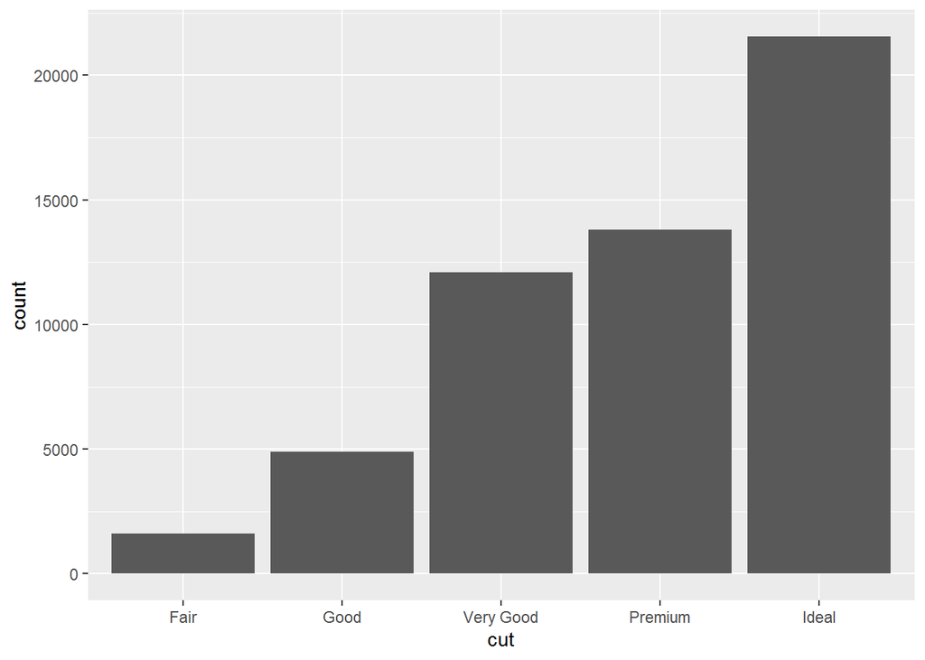

```r
ggplot(data = diamonds) +
  geom_bar(mapping = aes(x = cut))
```

- x축은 cut!, 그렇다면 y축은??

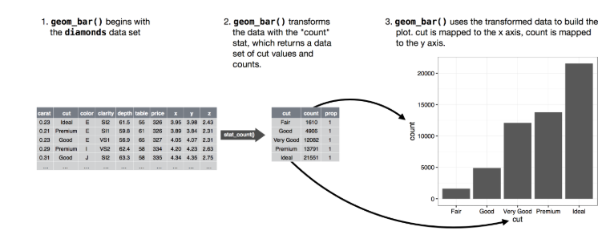

  ```
   ?geom_bar
  ```

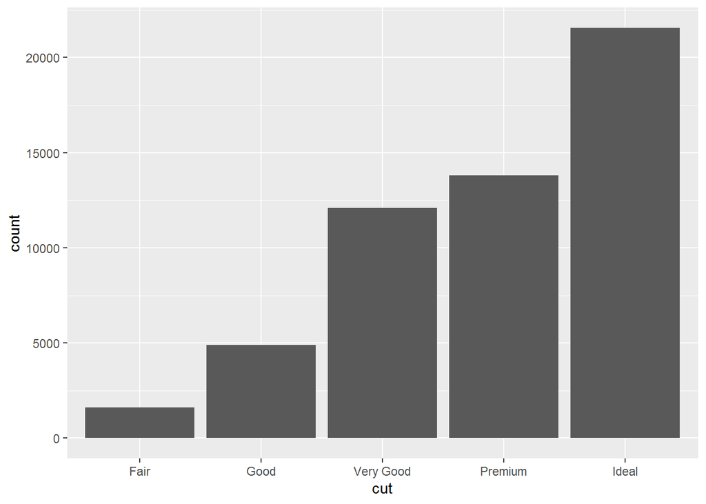

```r
ggplot(data = diamonds) +
  stat_count(mapping = aes(x = cut))
```

- 그래프에 사용할 새로운 값을 계산하는 알고리즘은 통계적 변환의 줄임말인 **스탯(stat)**이라고 부른다.

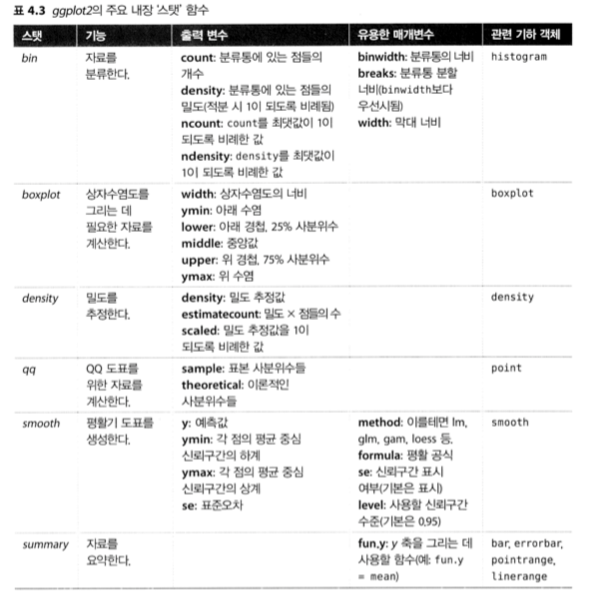

- 명시적으로 스탯을 사용해야 하는 **세가지 이유**
1. 기본 스탯을 덮어쓰고 싶을 수 있다.

   demo <- tribble( ~cut, ~freq, “Fair”, 1610, “Good”, 4906, “Very Good”, 12082, “Premium”, 13791, “Ideal”, 21551 )

ggplot(data = demo) + geom_bar(mapping = aes(x = cut, y = freq), stat = “identity”)

2. 변환된 변수에서 심미성으로 기본 매핑을 덮어쓰고자 할 수 있다. 예를 들어 빈도가 아니라 비율의 막대 그래프를 표시하고자 할 수 있다.

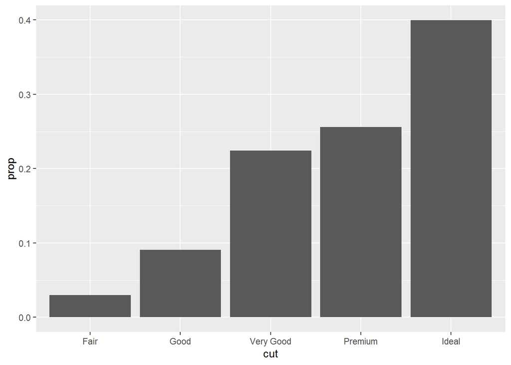

```r
ggplot(data = diamonds) +
            geom_bar(mapping = aes(x = cut, y = stat(prop), group = 1))
```

3. 코드에서 통계적 변환에 주의를 많이 집중시키고자 할 수 있다.

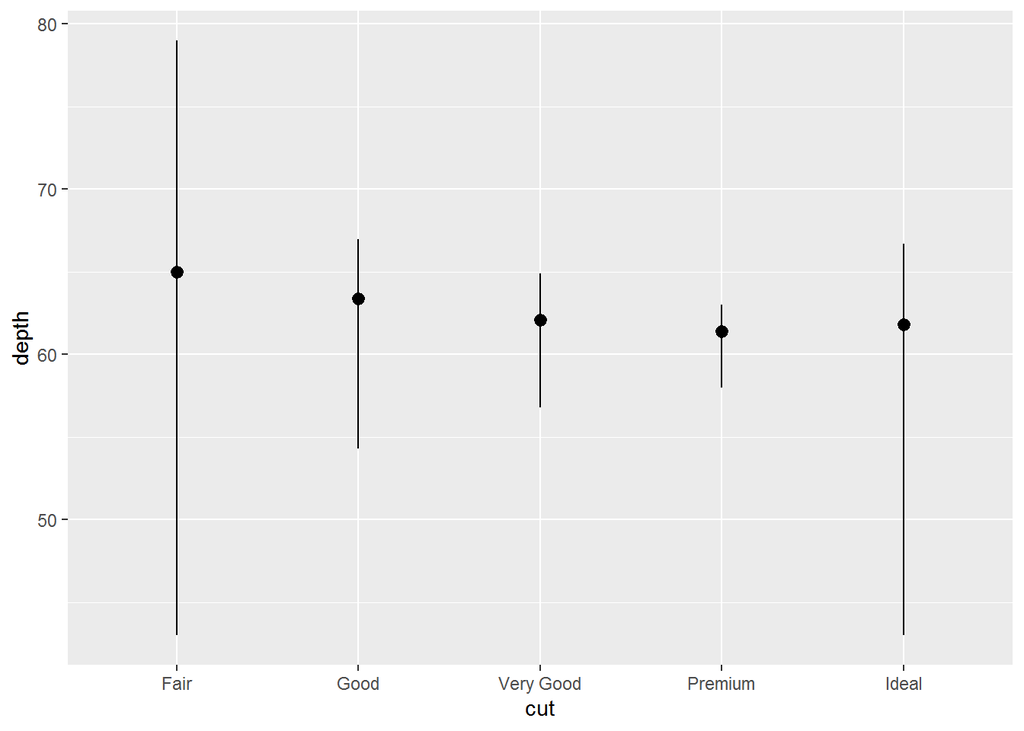

```r
ggplot(data = diamonds) +
  stat_summary(
  mapping = aes(x = cut, y = depth),
  fun.ymin = min,
  fun.ymax = max,
  fun.y = median)
```

*1.7.1 연습문제*

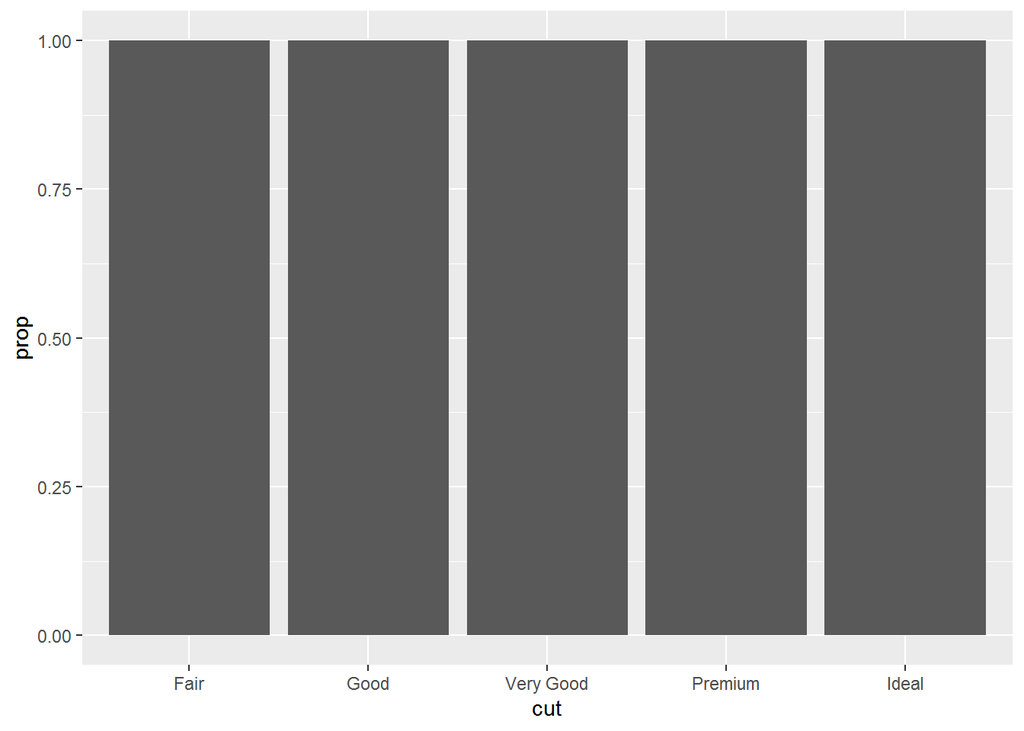

```r
ggplot(data = diamonds) +
           geom_bar(mapping = aes(x = cut, y = ..prop..))
```

## 1.8 위치 조정

- 막대그래프에 색상을 입힐 수 있는데 color 또는 fill을 이용하면 된다.

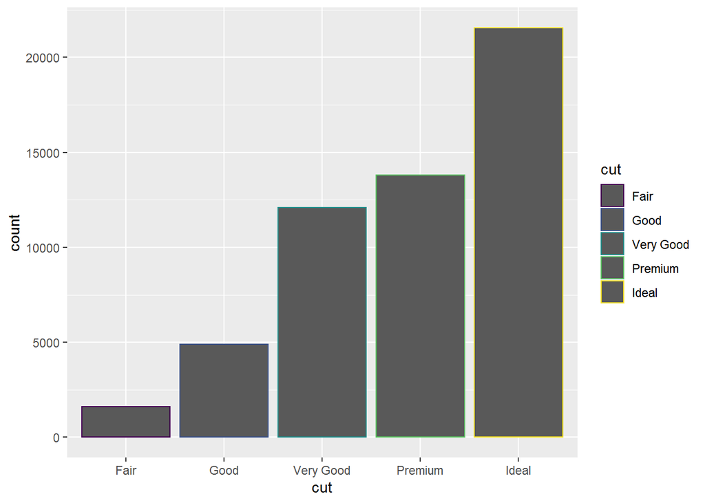

```r
ggplot(data = diamonds) +
  geom_bar(mapping = aes(x = cut, colour = cut))
```

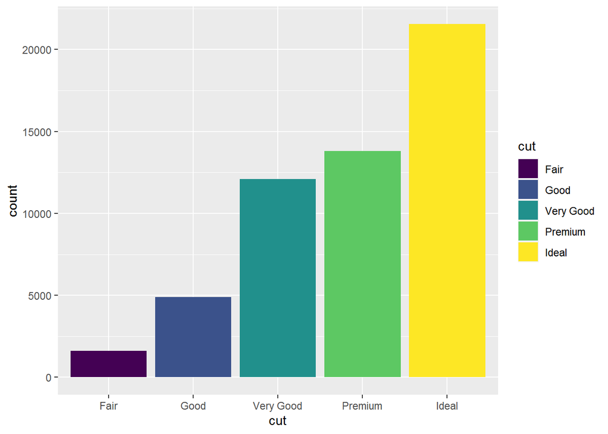

```r
ggplot(data = diamonds) +
  geom_bar(mapping = aes(x = cut, fill = cut))
```

- fill 심미성을 clarity에 매핑하면 각각의 색상이 입혀진 직사각형은 cut과 clarity의 조합을 나타낸다.

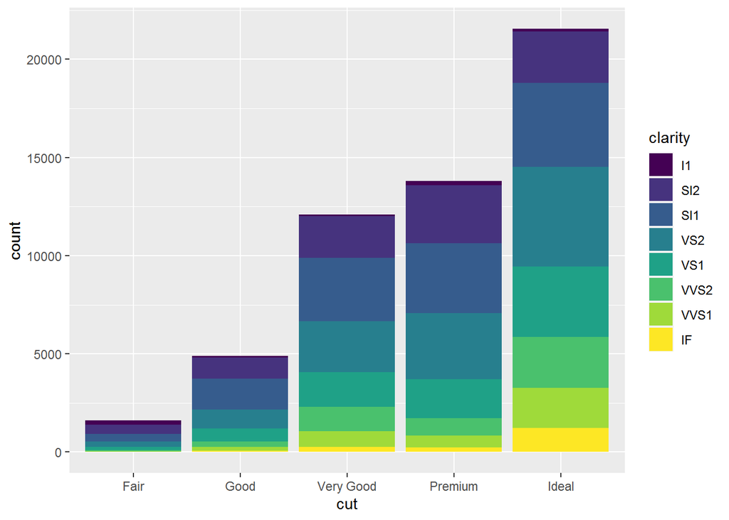

```r
ggplot(data = diamonds) +
  geom_bar(mapping = aes(x = cut, fill = clarity))
```

- position = “identity”를 하면 각 객체를 그래프 문맥에 해당되는 곳에 정확히 배치한다. 막대와 겹치기 떄문에 막대에 대해서는 그다지 유용하지 않다. 겹치는 것을 구별하려면 alpha를 작은 값으로 설정하여 막대들을 약간 투명하게하거나, fill = NA 로 설정하여 완전히 투명하게 해야한다.

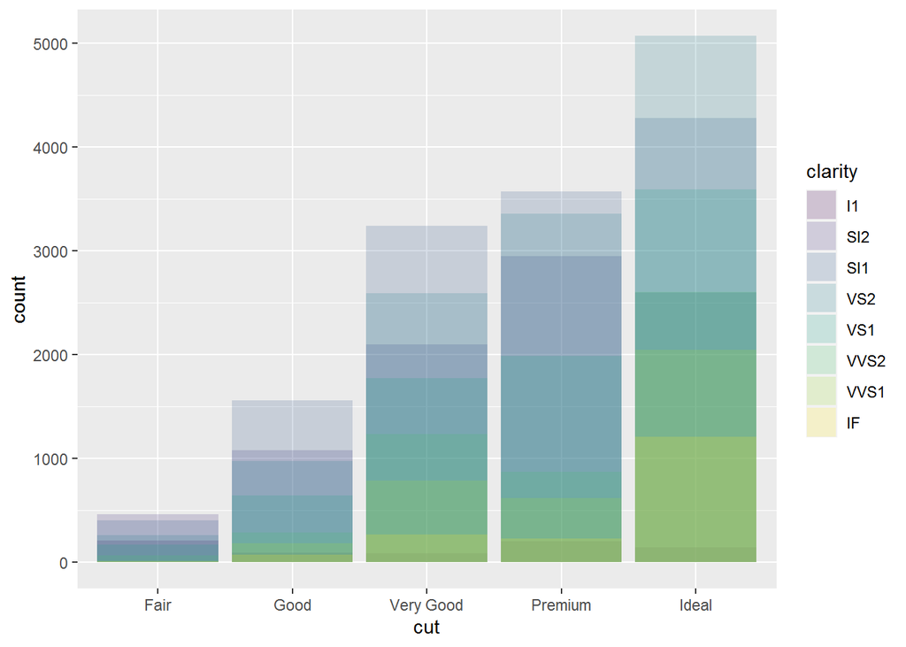

```r
ggplot(data = diamonds, mapping = aes(x = cut, fill = clarity)) +
 geom_bar(alpha = 1/5, position = "identity")
```

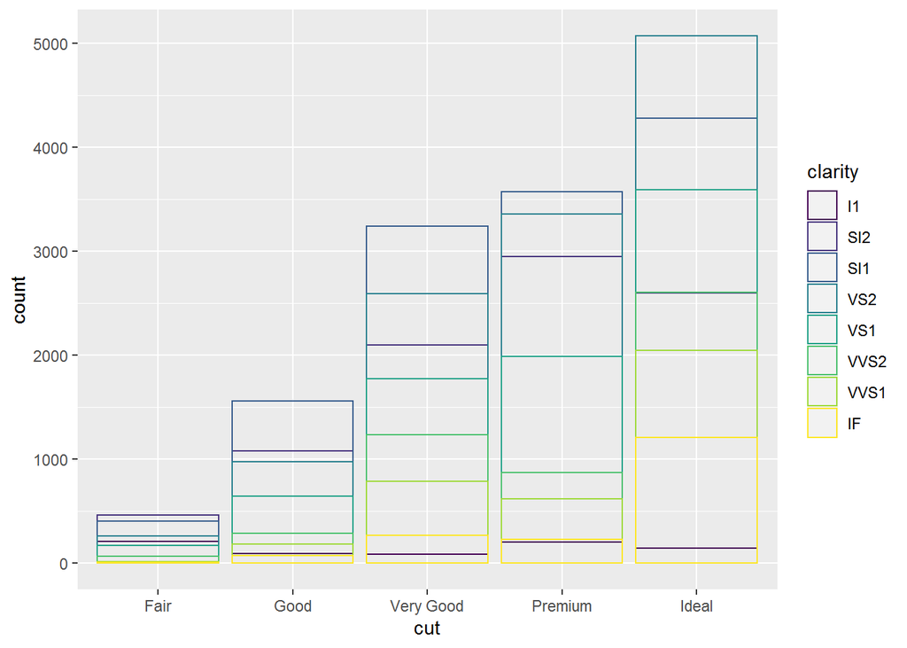

```r
ggplot(data = diamonds, mapping = aes(x = cut, colour = clarity)) +
geom_bar(fill = NA, position = "identity")
```

- position = “fill” 은 누적 막대들이 동일한 높이가 되어 그룹들 사이의 비율을 비교하기 쉬워진다.

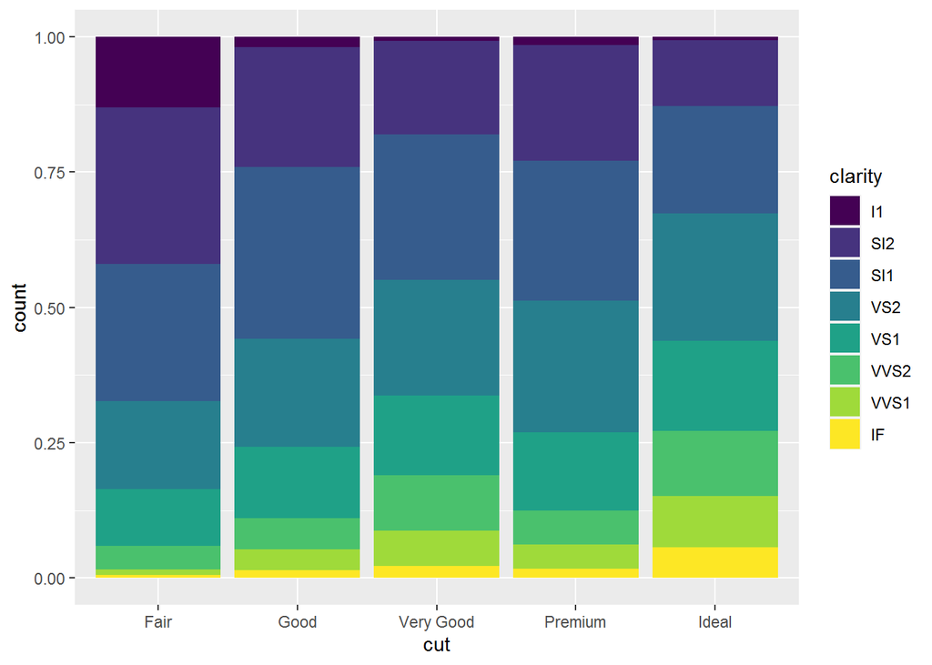

```r
ggplot(data = diamonds) +
 geom_bar(
 mapping = aes(x = cut, fill = clarity), position = "fill")
```

- position = “dodge”를 하면 겹치는 객체가 서로 옆에 배치된다. 이렇게 하면 개별 값들을 비교하기 쉬워진다.

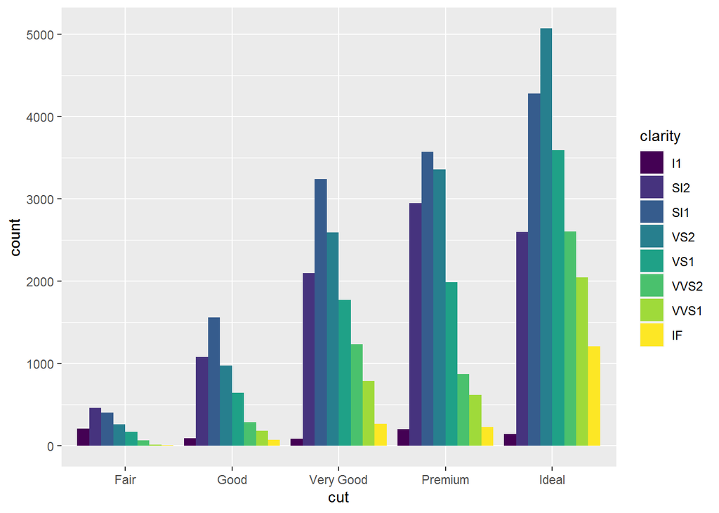

```r
ggplot(data = diamonds) +
  geom_bar(mapping = aes(x = cut, fill = clarity), position = "dodge")
```

- 산점도 형식에서 실제 데이터 값은 234개의 관측값이 있는데 126개만 표시되어 있다. 이 문제를 “오버플롯팅”이라고 한다.

```r
ggplot(data = mpg) +
  geom_point(mapping = aes(x = displ, y = hwy))
```

[output not shown]

- 이 떄 position = “jitter”를 하면 랜덤 노이즈가 추가되어 어 느 두 점도 같은 양의 랜덤 노이즈를 받을 가능성이 없기 때문에 포인트가 퍼지게 된다.

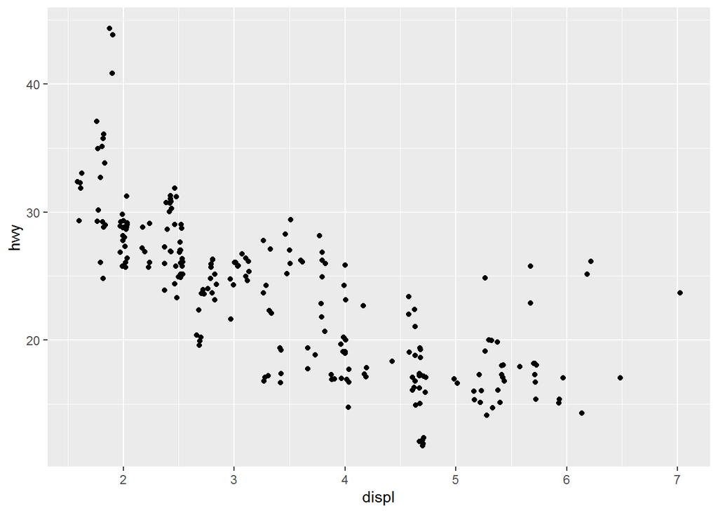

```r
ggplot(data = mpg) +
  geom_point(mapping = aes(x = displ, y = hwy), position = "jitter")
```

*1.8.1 연습문제*

1. 다음 플롯의 문제는 무엇인가? 어떻게 고치겠는가?

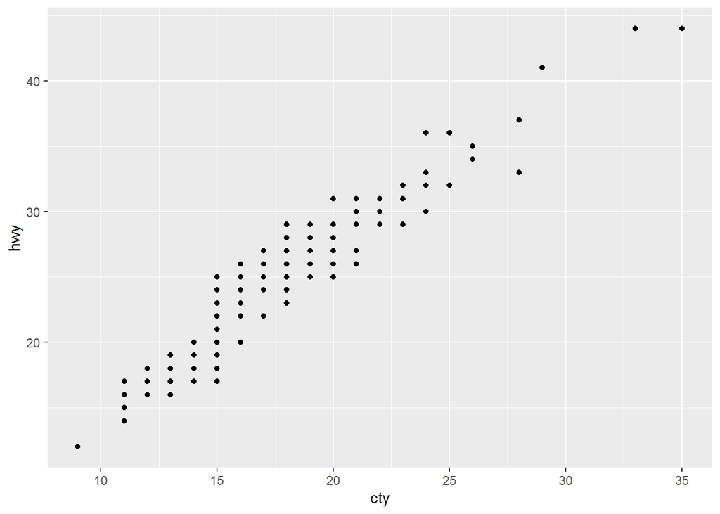

```r
ggplot(data = mpg, mapping = aes(x = cty, y = hwy)) +
  geom_point()
```

2. geom_jitter()에서 지터의 정도를 제어하는 파라미터들은 무엇인가?
3. geom_jitter()에서 geom_count()를 비교 대조하라.
4. geom_boxplot()의 위치 조정 기본값은 무엇인가? mpg 데이터셋 시각화를 생성하여 이를 표시하라.

## 1.9 좌표계

- coord_flip()은 x와 y축을 바꾼다.
- (예를 들어) 수평 박스 플롯이 필요할 때 유용
- 라벨이 길어서 x축과 겹치지 않고 들어맞게 하기 힘들 경우에도 유용

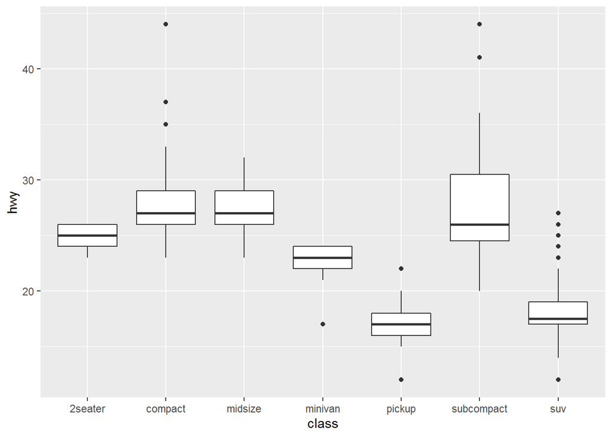

```r
ggplot(data = mpg, mapping = aes(x = class, y = hwy)) +
  geom_boxplot()
```

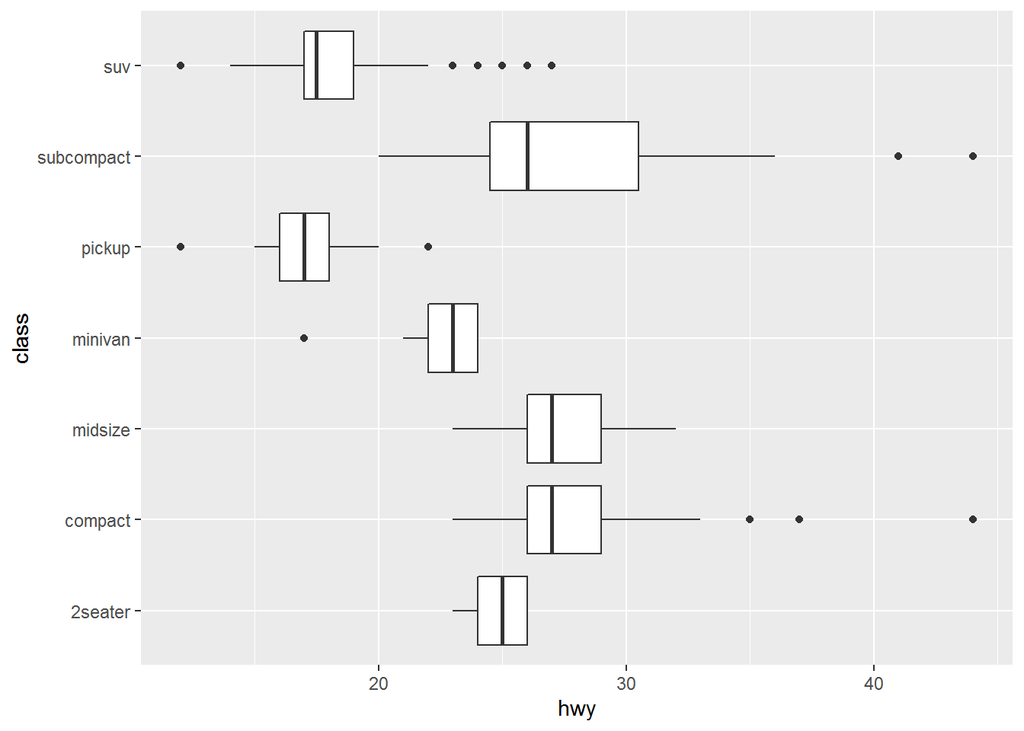

```r
ggplot(data = mpg, mapping = aes(x = class, y = hwy)) +
  geom_boxplot() +
  coord_flip()
```

- coord_polar()는 극좌표를 사용한다. 극좌표를 사용하면 막대 그래프와 Coxcomb차트 사이의 흥미로운 관계를 볼 수 있다.

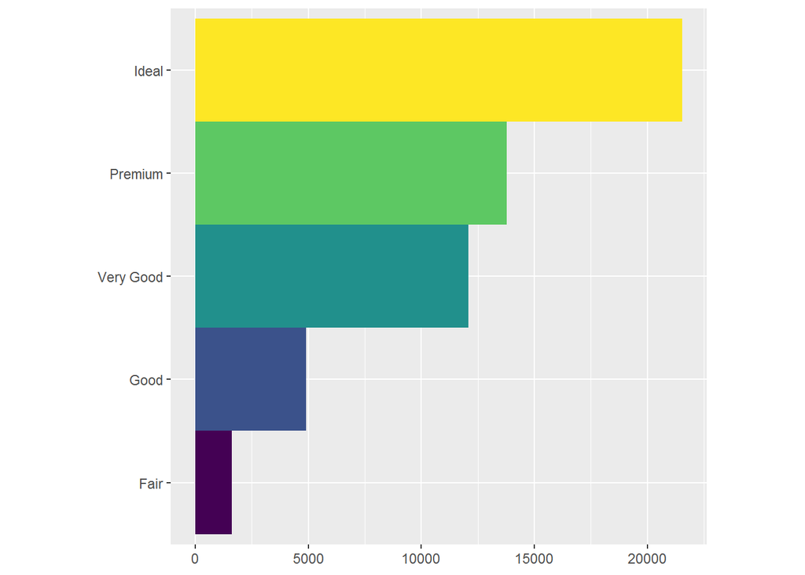

```r
 bar <- ggplot(data = diamonds) +
  geom_bar(
  mapping = aes(x = cut, fill = cut),
  show.legend = FALSE,
  width = 1) +
  theme(aspect.ratio = 1) +
  labs(x = NULL, y = NULL)
  bar + coord_flip()
```

```r
  bar + coord_polar()
```

[figure not shown]

*1.9.1 연습문제*

## 1.10 그래프 레이어 문법

```
     ggplot(data = <데이터>) +
        <지옴 함수>(
          mapping = aes(<매핑모음>),
         stat = <스탯>,
         position = <위치>
         ) +
        <좌표계 함수> +
        <면분할 함수>
```